# L3 plan

Geoffrey Millard

9/13/2021

## Goals

- Get my data out! (exporting, `write.csv()`, or use an RMarkdown)
- Explore dates (`lubridate`)
- Summarize data (`dplyr` from `tidyverse`)
- Generate custom categories
- Switch between data frame formats (long v. wide)
- Linear regression and correlation (`lm()`, `cor()`)
- Shapiro-Wilks, normality test (personally, I failed this test)
- ANOVA
- Tukey Honestly Significant Difference Time allowing
- ANOVA contrasts

## Best Practice

Always start your code by cleaning out your environment.

```r
rm(list = ls(all.names = TRUE))
```

## Needed Packages

If we cover everything these are the packages we will need. I’ll introduce them when we start using each package.

```r
library(dataRetrieval)
library(tidyverse)
library(tidyselect)
library(lubridate) # Part of tidyverse
library(kableExtra)
library(broom) # part of tidyverse
# time allowing
library(multcomp)
```

## Where we left off

We were importing actual data from NWIS and cleaning it up for today.

```r
#USGS and EPA dataset retrieval package
# library(dataRetrieval)
#click on "Packages" tab to see functions available in the dataRetrival package

#these are the USGS sites upstream from Honnedaga Lake, NY that we found in the browser
sites <- c('0134277112', '0134277114')

#detailed location information about the site
# readNWISsite(c('0134277112', '0134277114'))

#whatNWISdata displays the datasets available at each site
available <- whatNWISdata(siteNumber=c('0134277112', '0134277114'))
actual <- readNWISpCode(parameterCd = available$parm_cd) #interpret parameter codes
want <- c('00681', '00945', '50287', '50285', '00403', '00409') #we want: DOC, DSO4, DHg and DMeHg
data <- readNWISqw(siteNumbers = sites, parameterCd=want) #get the data
codes <- readNWISpCode(parameterCd = unique(data$parm_cd)) #confirms that we got what we wanted, shows UNITS!
# View(data)
```

```r
data <- data %>% mutate(Analyte = recode(parm_cd,
                         '00403'  = 'pH',
                         '00409'  = 'Alkalinity',
                         '00681' = "DOC",
                         '00945' = "SO4",
                         '50287' = "Hg",
                         '50285' = "MeHg"))

data <- data %>% mutate(Site = recode(site_no,
                         '0134277112' = "Reference",
                         '0134277114' = "Treated"))
colnames(data)
```

```
##  [1] "agency_cd"                           "site_no"
##  [3] "sample_dt"                           "sample_tm"
##  [5] "sample_end_dt"                       "sample_end_tm"
##  [7] "tm_datum_rlbty_cd"                   "coll_ent_cd"
##  [9] "medium_cd"                           "project_cd"
## [11] "aqfr_cd"                             "tu_id"
## [13] "body_part_id"                        "hyd_cond_cd"
## [15] "samp_type_cd"                        "hyd_event_cd"
## [17] "sample_lab_cm_tx"                    "parm_cd"
## [19] "remark_cd"                           "result_va"
## [21] "val_qual_tx"                         "meth_cd"
## [23] "dqi_cd"                              "rpt_lev_va"
## [25] "rpt_lev_cd"                          "lab_std_va"
## [27] "prep_set_no"                         "prep_dt"
## [29] "anl_set_no"                          "anl_dt"
## [31] "result_lab_cm_tx"                    "anl_ent_cd"
## [33] "sample_start_time_datum_cd_reported" "sample_end_time_datum_cd_reported"
## [35] "startDateTime"                       "tz_cd"
## [37] "Analyte"                             "Site"
```

```r
data1 <- data %>% dplyr::select(Site, Date=sample_dt, Time=sample_tm, Analyte, Result=result_va)

data1$Treatment <- NA
data1$Treatment[ data1$Date < ymd('2013-10-1')  ] <- 1
data1$Treatment[ data1$Date >= ymd('2013-10-1') ] <- 2
data1$Treatment[ data1$Date > mdy('2014-02-28') ] <- 3  # error because I am using the wrong lubridate function
data1$Treatment[ data1$Date > ymd('2014-02-28') ] <- 3
```

It would also be nice to set this as a factor or categorical variable. This will be useful if you want your categorical data to always display in the same order when plotting or summarizing.

```r
data1$Treatment <- factor(data1$Treatment, levels = c(1, 2, 3), labels = c('Pre-Treatment', 'Transitional', 'Post-Treatment'), ordered = T)
head(data1$Treatment)
```

```
## [1] Pre-Treatment Pre-Treatment Pre-Treatment Pre-Treatment Pre-Treatment
## [6] Pre-Treatment
## Levels: Pre-Treatment < Transitional < Post-Treatment
```

## Checking out already (exporting)?

Maybe this is all you needed to do and now you’re sharing it with a colleague who is going to do everything else (wouldn’t that be lovely!). If you are working in an Rmarkdown, the html output copies into MS Office applications very nicely, or you can output to a word document.

If you want something systematic (eg. because your doing this with lots of datasets) the baseR `write.csv` function is pretty useful. You do need to specify the dataframe and the filename and it will appear in your working directory.

```r
write.csv(data1, 'Simplified_long_format.csv')
```

Where did it go? Right now, it went to the default working directory for your R session (aka. probably not where you really want it).

You can probably see it in the files tab of the bottom right RStudio window. The easiest way to change the working directory is by clicking Session > Set Working Directory > Choose Directory

R will then conveniently print the code in the console, which you can copy and paste into your script (so you won’t have repeat the annoying point and click procedure)

```r
setwd("~/Projects/intro_to_R_2021/session_4")
```

Now if we write.csv again it will appear in our working directory (which you can see in the RStudio files tab, click More > Go to working directory)

## Get back in here (importing)!

baseR works nicely for .csv files

```r
imp <- read.csv('Simplified_long_format.csv')
```

There are packages for importing/exporting excel (eg. readxl) but I won’t take the time to cover them here as they work fairly similarly to the baseR function.

## Wide instead of Long data

Maybe that colleague isn’t happy with the long format data (analyte and result column). Maybe they want a wide format where each analyte has it’s own column. What a pain in excel, but fear not! `tidyverse` is here

```r
data_wide <- data1 %>% pivot_wider(names_from = Analyte, values_from = Result)

data1[,-3] %>% pivot_wider(names_from = Analyte, values_from = Result)  # example issue, remove the time column
```

```
## # A tibble: 332 x 9
##    Site    Date       Treatment   pH      Alkalinity DOC     SO4     MeHg  Hg
##    <chr>   <date>     <ord>       <list>  <list>     <list>  <list>  <lis> <lis>
##  1 Refere~ 2011-05-16 Pre-Treatm~ <dbl [~ <dbl [1]>  <dbl [~ <dbl [~ <NUL~ <NUL~
##  2 Refere~ 2011-06-06 Pre-Treatm~ <dbl [~ <dbl [1]>  <dbl [~ <dbl [~ <NUL~ <NUL~
##  3 Refere~ 2011-07-19 Pre-Treatm~ <dbl [~ <dbl [1]>  <dbl [~ <dbl [~ <NUL~ <NUL~
##  4 Refere~ 2011-08-01 Pre-Treatm~ <dbl [~ <dbl [1]>  <dbl [~ <dbl [~ <NUL~ <NUL~
##  5 Refere~ 2011-10-07 Pre-Treatm~ <dbl [~ <dbl [1]>  <dbl [~ <dbl [~ <NUL~ <NUL~
##  6 Refere~ 2011-10-31 Pre-Treatm~ <dbl [~ <dbl [1]>  <dbl [~ <dbl [~ <NUL~ <NUL~
##  7 Refere~ 2011-11-15 Pre-Treatm~ <dbl [~ <dbl [1]>  <dbl [~ <dbl [~ <NUL~ <NUL~
##  8 Refere~ 2011-11-30 Pre-Treatm~ <dbl [~ <dbl [1]>  <dbl [~ <dbl [~ <NUL~ <NUL~
##  9 Refere~ 2011-12-01 Pre-Treatm~ <dbl [~ <dbl [1]>  <dbl [~ <dbl [~ <NUL~ <NUL~
## 10 Refere~ 2012-01-25 Pre-Treatm~ <dbl [~ <dbl [1]>  <dbl [~ <dbl [~ <NUL~ <NUL~
## # ... with 322 more rows
```

```r
View(data_wide)
```

There are some things that work better with long data, so we can go the other way as well with `tidyverse`

## Exercise Break 1

Can you use data_wide and the `pivot_longer()` function to generate a long format df?

```r
data_wide %>% pivot_longer(colnames(data_wide)[5:8], names_to='Name', values_to='Value')
```

```
## # A tibble: 1,752 x 8
##    Site      Date       Time  Treatment      MeHg    Hg Name        Value
##    <chr>     <date>     <chr> <ord>         <dbl> <dbl> <chr>       <dbl>
##  1 Reference 2011-05-16 00:00 Pre-Treatment    NA    NA pH           4.59
##  2 Reference 2011-05-16 00:00 Pre-Treatment    NA    NA Alkalinity -21.3
##  3 Reference 2011-05-16 00:00 Pre-Treatment    NA    NA DOC          4.93
##  4 Reference 2011-05-16 00:00 Pre-Treatment    NA    NA SO4          2.63
##  5 Reference 2011-06-06 09:25 Pre-Treatment    NA    NA pH           4.73
##  6 Reference 2011-06-06 09:25 Pre-Treatment    NA    NA Alkalinity -11.4
##  7 Reference 2011-06-06 09:25 Pre-Treatment    NA    NA DOC          3.72
##  8 Reference 2011-06-06 09:25 Pre-Treatment    NA    NA SO4          3.24
##  9 Reference 2011-07-19 12:25 Pre-Treatment    NA    NA pH           4.62
## 10 Reference 2011-07-19 12:25 Pre-Treatment    NA    NA Alkalinity -14.2
## # ... with 1,742 more rows
```

## That thing everybody loves: dating

The lubridate package is a huge improvement over managing dates with baseR (eg. baseR months go from 0-11, so don’t get tripped up!), because it makes it easier to separate days, months and years.

First, Lets check and see if our Date data is actually a date.

```r
str(data1$Date) # can also use this on the whole data frame, but that can be hard to follow on a larger dataset
```

```
##  Date[1:1774], format: "2011-05-16" "2011-05-16" "2011-05-16" "2011-05-16" "2011-06-06" ...
```

```r
class(data1$Date)
```

```
## [1] "Date"
```

## Look at these: Summary stats

Now that we have cleaned data, we want to take a quick look at it. The fastest, simplest method is called ‘piping’ (`%>%`) and is part of the `dplyr` package. We can use this to generate an overall average for each site, analyte or any other variable with a column in the data frame.

```r
Table1 <- data1[data1$Analyte=='DOC',] %>%
  group_by(Site, Analyte, year(Date)) %>%
  summarize(average=mean(Result), n=n())
Table1
```

```
## # A tibble: 18 x 5
## # Groups:   Site, Analyte [2]
##    Site      Analyte `year(Date)` average     n
##    <chr>     <chr>          <dbl>   <dbl> <int>
##  1 Reference DOC             2011    4.15     9
##  2 Reference DOC             2012    4.35    24
##  3 Reference DOC             2013    5.12    36
##  4 Reference DOC             2014    4.64    20
##  5 Reference DOC             2015    4.61    26
##  6 Reference DOC             2016    4.81    19
##  7 Reference DOC             2017    7.16     8
##  8 Reference DOC             2018    5.76    25
##  9 Reference DOC             2019    6.02    23
## 10 Treated   DOC             2011    5.02     7
## 11 Treated   DOC             2012    5.35    19
## 12 Treated   DOC             2013    8.23    36
## 13 Treated   DOC             2014    8.64    30
## 14 Treated   DOC             2015    8.31    20
## 15 Treated   DOC             2016    7.88    26
## 16 Treated   DOC             2017   11.9      8
## 17 Treated   DOC             2018    7.99    30
## 18 Treated   DOC             2019    9.09    25
```

This is wonderful, but does not actually look like a publishable table. `kableExtra` to save the day!

```r
kable(Table1) %>%
  kable_styling(bootstrap_options = c('striped', 'hover'), full_width = F)
```

| Site | Analyte | year(Date) | average | n |
| --- | --- | --- | --- | --- |
| Reference | DOC | 2011 | 4.153333 | 9 |
| Reference | DOC | 2012 | 4.345833 | 24 |
| Reference | DOC | 2013 | 5.125000 | 36 |
| Reference | DOC | 2014 | 4.637500 | 20 |
| Reference | DOC | 2015 | 4.606154 | 26 |
| Reference | DOC | 2016 | 4.807368 | 19 |
| Reference | DOC | 2017 | 7.158750 | 8 |
| Reference | DOC | 2018 | 5.759600 | 25 |
| Reference | DOC | 2019 | 6.017391 | 23 |
| Treated | DOC | 2011 | 5.017143 | 7 |
| Treated | DOC | 2012 | 5.348421 | 19 |
| Treated | DOC | 2013 | 8.234722 | 36 |
| Treated | DOC | 2014 | 8.642667 | 30 |
| Treated | DOC | 2015 | 8.312000 | 20 |
| Treated | DOC | 2016 | 7.881154 | 26 |
| Treated | DOC | 2017 | 11.862500 | 8 |
| Treated | DOC | 2018 | 7.987667 | 30 |
| Treated | DOC | 2019 | 9.090800 | 25 |

# Exercise break 2

For each site, analyte, and month, generate the mean, standard deviation, maximum and minimum values, and the n-value.

```r
Table2 <- data1 %>%
  group_by(Site, Analyte, month(Date)) %>%
  summarize(average=mean(Result, na.rm=T),
            stdv=sd(Result, na.rm=T),
            max=max(Result, na.rm=T),
            min=min(Result, na.rm=T),
            n = n())
Table2
```

```
## # A tibble: 136 x 8
## # Groups:   Site, Analyte [12]
##    Site      Analyte    `month(Date)` average  stdv   max   min     n
##    <chr>     <chr>              <dbl>   <dbl> <dbl> <dbl> <dbl> <int>
##  1 Reference Alkalinity             1   -24.7  14.2   0   -40.1     7
##  2 Reference Alkalinity             2   -29.6  15.6  -5.7 -44       5
##  3 Reference Alkalinity             3   -22.8  13.0   0   -45.4    16
##  4 Reference Alkalinity             4   -23.3  14.5   9.3 -48.8    15
##  5 Reference Alkalinity             5   -24.7  13.6  -3.9 -53.2    13
##  6 Reference Alkalinity             6   -27.9  17.2   0.1 -75.2    29
##  7 Reference Alkalinity             7   -29.0  19.4  -0.5 -63.7    20
##  8 Reference Alkalinity             8   -23.2  14.5  11.8 -53.2    23
##  9 Reference Alkalinity             9   -29.1  16.7  -8.8 -60.3    15
## 10 Reference Alkalinity            10   -29.0  16.2  -0.5 -68.4    33
## # ... with 126 more rows
```

```r
Table2 %>% kable() %>%
kable_styling(bootstrap_options = c('striped', 'hover'), full_width = F)
```

| Site | Analyte | month(Date) | average | stdv | max | min | n |
| --- | --- | --- | --- | --- | --- | --- | --- |
| Reference | Alkalinity | 1 | -24.6857143 | 14.2470381 | 0.00 | -40.100 | 7 |
| Reference | Alkalinity | 2 | -29.5800000 | 15.6098366 | -5.70 | -44.000 | 5 |
| Reference | Alkalinity | 3 | -22.8000000 | 13.0268441 | 0.00 | -45.400 | 16 |
| Reference | Alkalinity | 4 | -23.3466667 | 14.5444082 | 9.30 | -48.800 | 15 |
| Reference | Alkalinity | 5 | -24.7076923 | 13.5983125 | -3.90 | -53.200 | 13 |
| Reference | Alkalinity | 6 | -27.9241379 | 17.2290796 | 0.10 | -75.200 | 29 |
| Reference | Alkalinity | 7 | -29.0150000 | 19.3761186 | -0.50 | -63.700 | 20 |
| Reference | Alkalinity | 8 | -23.1521739 | 14.4909021 | 11.80 | -53.200 | 23 |
| Reference | Alkalinity | 9 | -29.1466667 | 16.6603407 | -8.80 | -60.300 | 15 |
| Reference | Alkalinity | 10 | -29.0242424 | 16.1894841 | -0.50 | -68.400 | 33 |
| Reference | Alkalinity | 11 | -29.3100000 | 18.3030599 | -0.90 | -65.500 | 20 |
| Reference | Alkalinity | 12 | -26.9583333 | 12.9127462 | -3.80 | -43.500 | 12 |
| Reference | DOC | 1 | 3.4857143 | 0.3849180 | 4.05 | 2.850 | 7 |
| Reference | DOC | 2 | 4.2100000 | 0.6976747 | 4.77 | 3.180 | 5 |
| Reference | DOC | 3 | 3.3992308 | 0.5072715 | 4.38 | 2.750 | 13 |
| Reference | DOC | 4 | 4.0600000 | 0.5968249 | 5.21 | 3.080 | 13 |
| Reference | DOC | 5 | 5.2916667 | 1.0970442 | 8.05 | 3.950 | 12 |
| Reference | DOC | 6 | 5.4119231 | 1.3829361 | 9.33 | 3.640 | 26 |
| Reference | DOC | 7 | 4.5229412 | 0.9717431 | 6.56 | 3.020 | 17 |
| Reference | DOC | 8 | 5.0795455 | 1.1100600 | 7.80 | 3.580 | 22 |
| Reference | DOC | 9 | 5.6950000 | 1.0199076 | 7.42 | 4.030 | 14 |
| Reference | DOC | 10 | 6.4675758 | 1.8045862 | 13.40 | 4.150 | 33 |
| Reference | DOC | 11 | 5.3405000 | 1.2363336 | 8.11 | 3.890 | 20 |
| Reference | DOC | 12 | 4.3062500 | 0.5862700 | 5.29 | 3.640 | 8 |
| Reference | Hg | 1 | 0.5500000 | NA | 0.55 | 0.550 | 1 |
| Reference | Hg | 2 | 0.5300000 | NA | 0.53 | 0.530 | 1 |
| Reference | Hg | 3 | 0.3300000 | NA | 0.33 | 0.330 | 1 |
| Reference | Hg | 5 | 0.9000000 | NA | 0.90 | 0.900 | 1 |
| Reference | Hg | 6 | 1.0633333 | 0.3271595 | 1.44 | 0.850 | 3 |
| Reference | Hg | 7 | 0.9366667 | 0.2055075 | 1.15 | 0.740 | 3 |

[output cut: 106 more lines]

## Getting at the treatment

Maybe we want to look at the three treatment periods (novel idea).

```r
Table5 <- data1 %>%
  group_by(Treatment, Analyte, Site) %>%
  summarize(average=mean(Result, na.rm=T),
            stdv=sd(Result, na.rm=T),
            max=max(Result, na.rm=T),
            min=min(Result, na.rm=T),
            n = n())
Table5
```

```
## # A tibble: 36 x 8
## # Groups:   Treatment, Analyte [18]
##    Treatment     Analyte    Site      average    stdv   max    min     n
##    <ord>         <chr>      <chr>       <dbl>   <dbl> <dbl>  <dbl> <int>
##  1 Pre-Treatment Alkalinity Reference -24.4   15.0    11.8  -75.2     54
##  2 Pre-Treatment Alkalinity Treated   -30.5   14.6     6.1  -56.2     46
##  3 Pre-Treatment DOC        Reference   4.46   1.02    7.67   2.85    54
##  4 Pre-Treatment DOC        Treated     5.50   1.58   10.5    2.87    46
##  5 Pre-Treatment Hg         Reference   1.15  NA       1.15   1.15     1
##  6 Pre-Treatment Hg         Treated     1.39   0.141   1.49   1.29     2
##  7 Pre-Treatment MeHg       Reference   0.04  NA       0.04   0.04     1
##  8 Pre-Treatment MeHg       Treated     0.025  0.0212  0.04   0.01     2
##  9 Pre-Treatment pH         Reference   4.60   0.0850  4.91   4.41    54
## 10 Pre-Treatment pH         Treated     4.54   0.0890  4.92   4.4     46
## # ... with 26 more rows
```

```r
Table5 %>% kable() %>%
kable_styling(bootstrap_options = c('striped', 'hover'), full_width = F)
```

| Treatment | Analyte | Site | average | stdv | max | min | n |
| --- | --- | --- | --- | --- | --- | --- | --- |
| Pre-Treatment | Alkalinity | Reference | -24.4240741 | 14.9604376 | 11.80 | -75.20 | 54 |
| Pre-Treatment | Alkalinity | Treated | -30.5173913 | 14.6265102 | 6.10 | -56.20 | 46 |
| Pre-Treatment | DOC | Reference | 4.4600000 | 1.0161396 | 7.67 | 2.85 | 54 |
| Pre-Treatment | DOC | Treated | 5.4971739 | 1.5827552 | 10.50 | 2.87 | 46 |
| Pre-Treatment | Hg | Reference | 1.1500000 | NA | 1.15 | 1.15 | 1 |
| Pre-Treatment | Hg | Treated | 1.3900000 | 0.1414214 | 1.49 | 1.29 | 2 |
| Pre-Treatment | MeHg | Reference | 0.0400000 | NA | 0.04 | 0.04 | 1 |
| Pre-Treatment | MeHg | Treated | 0.0250000 | 0.0212132 | 0.04 | 0.01 | 2 |
| Pre-Treatment | pH | Reference | 4.5979630 | 0.0850389 | 4.91 | 4.41 | 54 |
| Pre-Treatment | pH | Treated | 4.5386957 | 0.0890096 | 4.92 | 4.40 | 46 |
| Pre-Treatment | SO4 | Reference | 2.8592593 | 0.4616126 | 3.79 | 1.89 | 54 |
| Pre-Treatment | SO4 | Treated | 3.0582609 | 0.5022142 | 4.06 | 1.96 | 46 |
| Transitional | Alkalinity | Reference | -33.9058824 | 13.8855802 | -8.20 | -60.50 | 17 |
| Transitional | Alkalinity | Treated | 203.6666667 | 237.2780474 | 851.00 | 2.40 | 18 |
| Transitional | DOC | Reference | 5.4335294 | 1.3399717 | 8.14 | 3.18 | 17 |
| Transitional | DOC | Treated | 10.5533333 | 4.0696105 | 18.40 | 3.90 | 18 |
| Transitional | Hg | Reference | 1.3671429 | 0.6127184 | 2.13 | 0.53 | 7 |
| Transitional | Hg | Treated | 3.2657143 | 1.7314239 | 5.50 | 1.07 | 7 |
| Transitional | MeHg | Reference | 0.0185714 | 0.0157359 | 0.05 | 0.01 | 7 |
| Transitional | MeHg | Treated | 0.0850000 | 0.0618870 | 0.19 | 0.02 | 7 |
| Transitional | pH | Reference | 4.5776471 | 0.0566270 | 4.66 | 4.49 | 17 |
| Transitional | pH | Treated | 6.5938889 | 0.6062919 | 7.46 | 5.51 | 18 |
| Transitional | SO4 | Reference | 2.5382353 | 0.2819183 | 2.99 | 2.13 | 17 |
| Transitional | SO4 | Treated | 3.6050000 | 0.7622972 | 6.44 | 2.96 | 18 |
| Post-Treatment | Alkalinity | Reference | -26.9262774 | 16.2058235 | 9.30 | -68.40 | 137 |
| Post-Treatment | Alkalinity | Treated | -0.7310559 | 18.7712654 | 56.80 | -68.60 | 161 |
| Post-Treatment | DOC | Reference | 5.3485714 | 1.5997327 | 13.40 | 2.75 | 119 |
| Post-Treatment | DOC | Treated | 8.6320438 | 3.1477945 | 18.80 | 3.31 | 137 |
| Post-Treatment | Hg | Reference | 0.9100000 | 0.3790251 | 1.61 | 0.33 | 11 |
| Post-Treatment | Hg | Treated | 2.3684615 | 0.9932761 | 4.11 | 0.69 | 13 |
| Post-Treatment | MeHg | Reference | 0.0997778 | 0.0644627 | 0.17 | 0.01 | 11 |
| Post-Treatment | MeHg | Treated | 0.1178182 | 0.0969142 | 0.26 | 0.01 | 12 |
| Post-Treatment | pH | Reference | 4.6075362 | 0.0660658 | 5.05 | 4.48 | 138 |
| Post-Treatment | pH | Treated | 5.0891304 | 0.1632842 | 5.67 | 4.66 | 161 |
| Post-Treatment | SO4 | Reference | 2.1751471 | 0.4291835 | 3.15 | 1.14 | 136 |
| Post-Treatment | SO4 | Treated | 2.6270732 | 0.6484346 | 4.17 | 1.19 | 164 |

## Basic statistics

Linear regressions and correlations are common test, and we can use this data to explore how baseR presents these results. The `lm()` function uses a formula syntax, while `cor()` does not.

```r
colnames(data_wide)
```

```
##  [1] "Site"       "Date"       "Time"       "Treatment"  "pH"
##  [6] "Alkalinity" "DOC"        "SO4"        "MeHg"       "Hg"
```

```r
reg1 <- lm(data=data_wide, Hg~DOC)
reg1
```

```
##
## Call:
## lm(formula = Hg ~ DOC, data = data_wide)
##
## Coefficients:
## (Intercept)          DOC
##      -1.141        0.511
```

```r
summary(reg1)
```

```
##
## Call:
## lm(formula = Hg ~ DOC, data = data_wide)
##
## Residuals:
##      Min       1Q   Median       3Q      Max
## -1.38719 -0.27662  0.02467  0.21783  0.78436
##
## Coefficients:
##             Estimate Std. Error t value Pr(>|t|)
## (Intercept) -1.14060    0.19002  -6.003 5.14e-07 ***
## DOC          0.51097    0.02997  17.050  < 2e-16 ***
## ---
## Signif. codes:  0 '***' 0.001 '**' 0.01 '*' 0.05 '.' 0.1 ' ' 1
##
## Residual standard error: 0.4381 on 39 degrees of freedom
##   (397 observations deleted due to missingness)
## Multiple R-squared:  0.8817, Adjusted R-squared:  0.8787
## F-statistic: 290.7 on 1 and 39 DF,  p-value: < 2.2e-16
```

```r
broom::tidy(summary(reg1)) %>% kable() %>% kable_styling(bootstrap_options = c('striped', 'hover'), full_width = F)
```

| term | estimate | std.error | statistic | p.value |
| --- | --- | --- | --- | --- |
| (Intercept) | -1.1406025 | 0.1900178 | -6.002608 | 5e-07 |
| DOC | 0.5109665 | 0.0299681 | 17.050331 | 0e+00 |

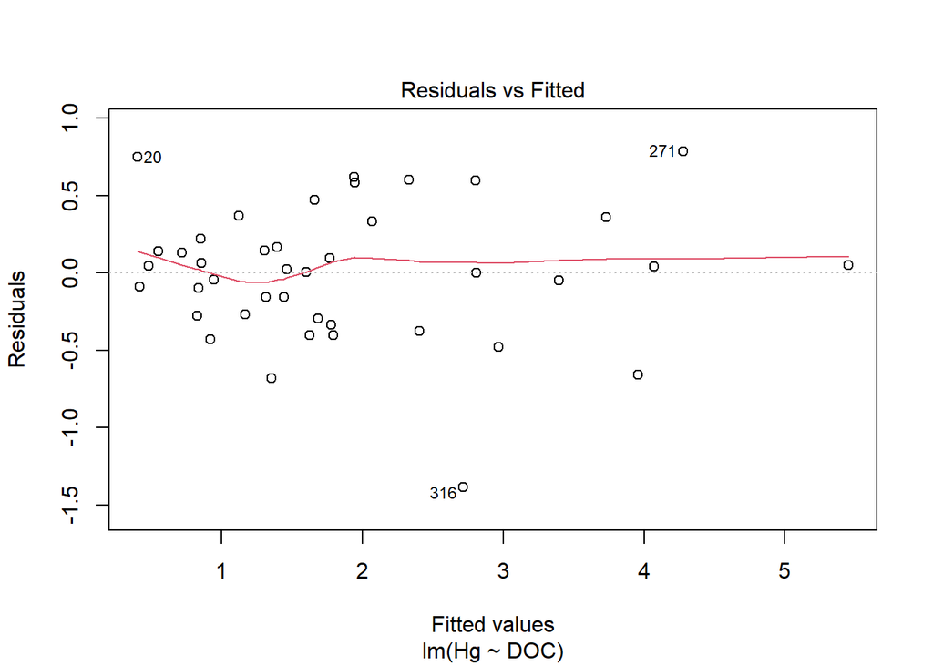

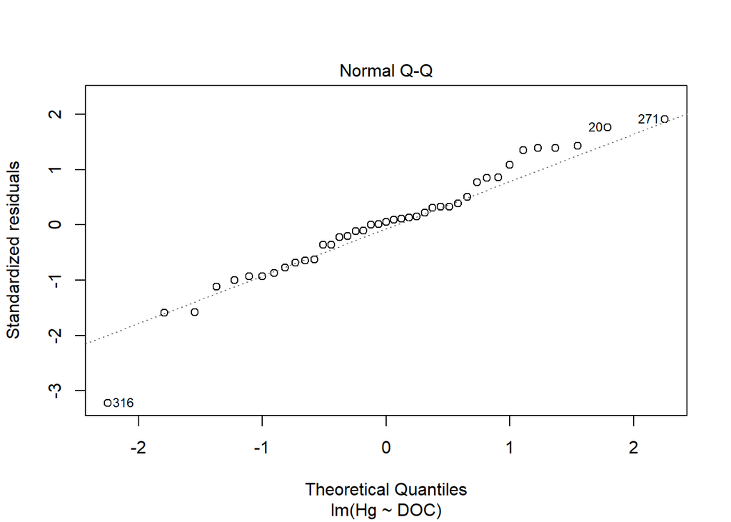

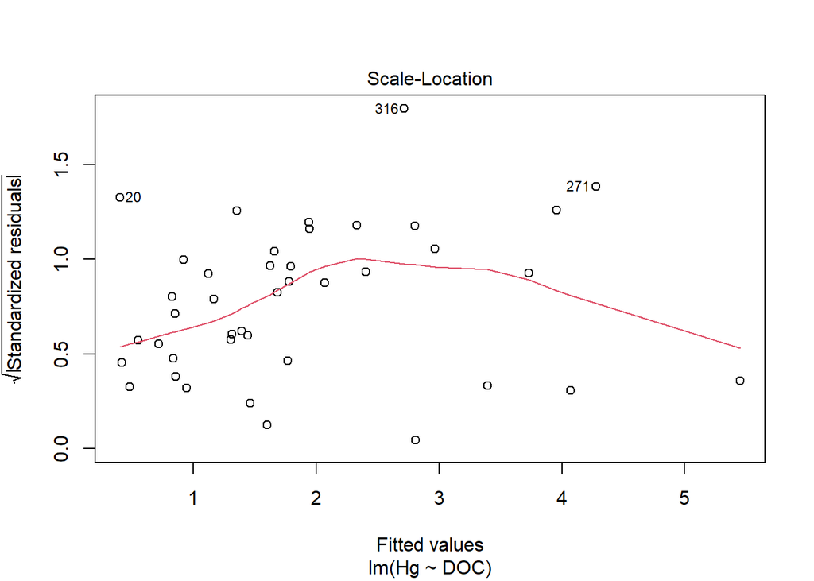

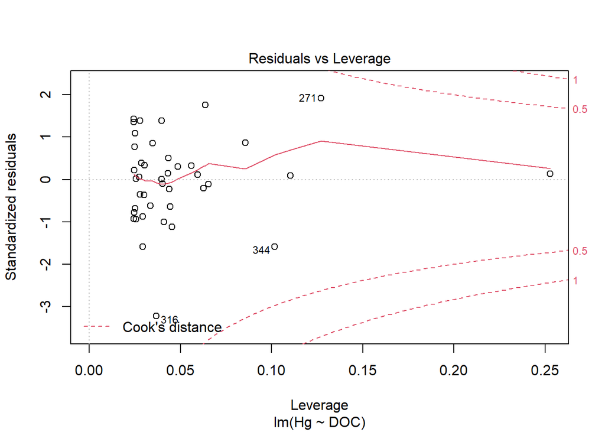

```r
plot(reg1)
```

## Exercise Break 3

Can you use the `cor()` function to generate a correlation between DOC and MeHg?

```r
cor(x=data_wide$DOC, y=data_wide$MeHg, use = 'complete.obs')
```

```
## [1] 0.2610306
```

## Normality and ANOVA

If you want to check that your data is normally distributed, you can use the `shapiro.test()` function. This performs a Shapiro-Wilks test where the null hypothesis states the data is normally distributed

```r
shapiro.test(data_wide$Alkalinity)
```

```
##
##  Shapiro-Wilk normality test
##
## data:  data_wide$Alkalinity
## W = 0.37685, p-value < 2.2e-16
```

```r
anova1 <- aov(data = data_wide, DOC~Treatment+Site+Treatment*Site)
summary(anova1)
```

```
##                 Df Sum Sq Mean Sq F value   Pr(>F)
## Treatment        2  416.7   208.4   37.71 1.11e-15 ***
## Site             1  803.9   803.9  145.49  < 2e-16 ***
## Treatment:Site   2  138.6    69.3   12.54 5.29e-06 ***
## Residuals      385 2127.3     5.5
## ---
## Signif. codes:  0 '***' 0.001 '**' 0.01 '*' 0.05 '.' 0.1 ' ' 1
## 47 observations deleted due to missingness
```

We can use this `aov()` object to perform a Tukey HSD test and generate a rough contrast plot.

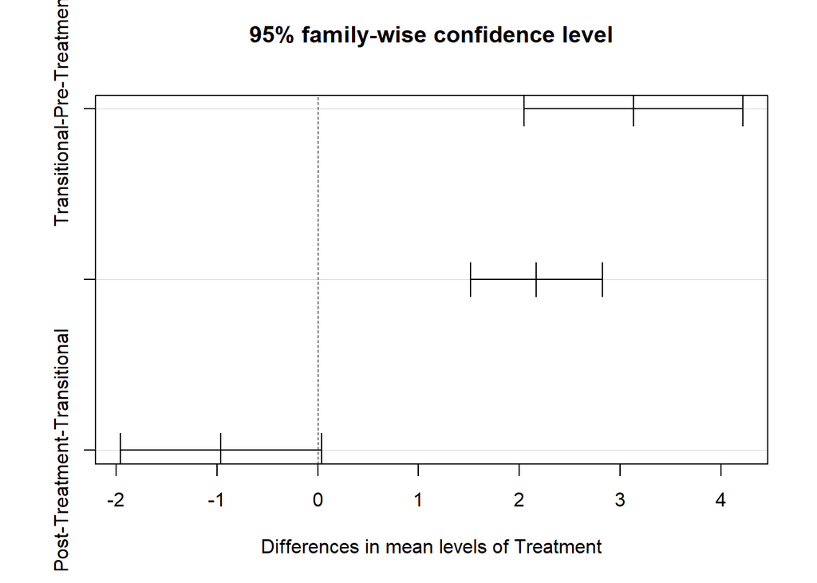

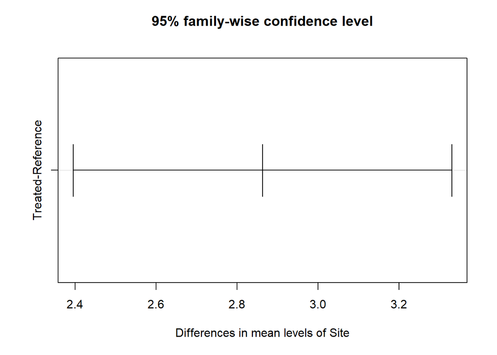

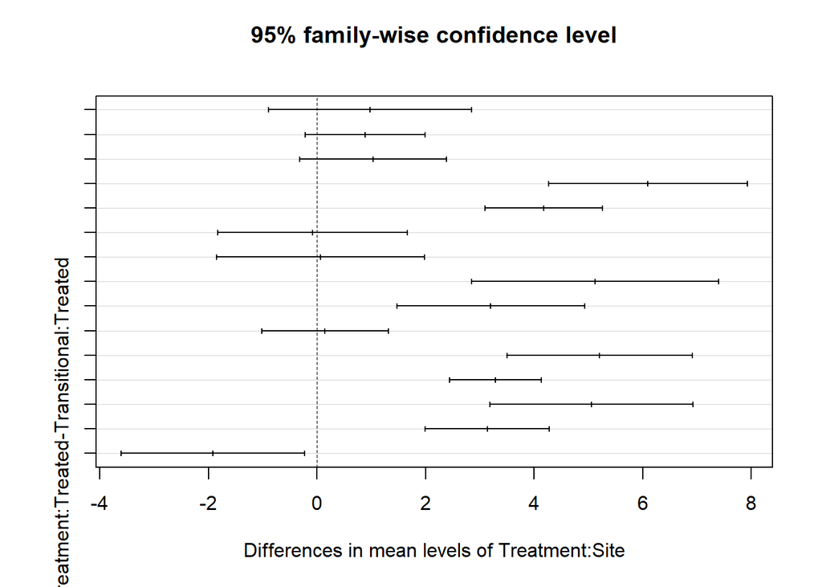

```r
test <- TukeyHSD(anova1)
plot(test)
```